# Machine Learning - Personal Activity

Thom

October 22, 2015

# Overview

The goal of this project is to predict the type of exercise a person did solely by movement data from tracking devices such as Jawbone Up, Nike FuelBand, or Fitbit. More information is available from the website here: http://groupware.les.inf.puc-rio.br/har (see the section on the Weight Lifting Exercise Dataset).

## Load & Clean Data

The training data is loaded.

Then nulls are removed as well unrelevant data i.e. timestamps, name, etc.

```r
training <- read.csv("pml-training.csv",
                   header=T,  na.strings = c("", "NA"))

#Get Rid of null data
data_names <- names(training[,colSums(is.na(training)) == 0])
train_data <- training[,c(data_names,"classe")]
#Get rid of . . .
train_data <- train_data[8:60]

# Training/Test set
inTrain = createDataPartition(train_data$classe, p = 0.6, list = F)
train = train_data[inTrain,]
train_test = train_data[-inTrain,]
```

## Data Exploration

First we take a look at histograms of the relevant data.

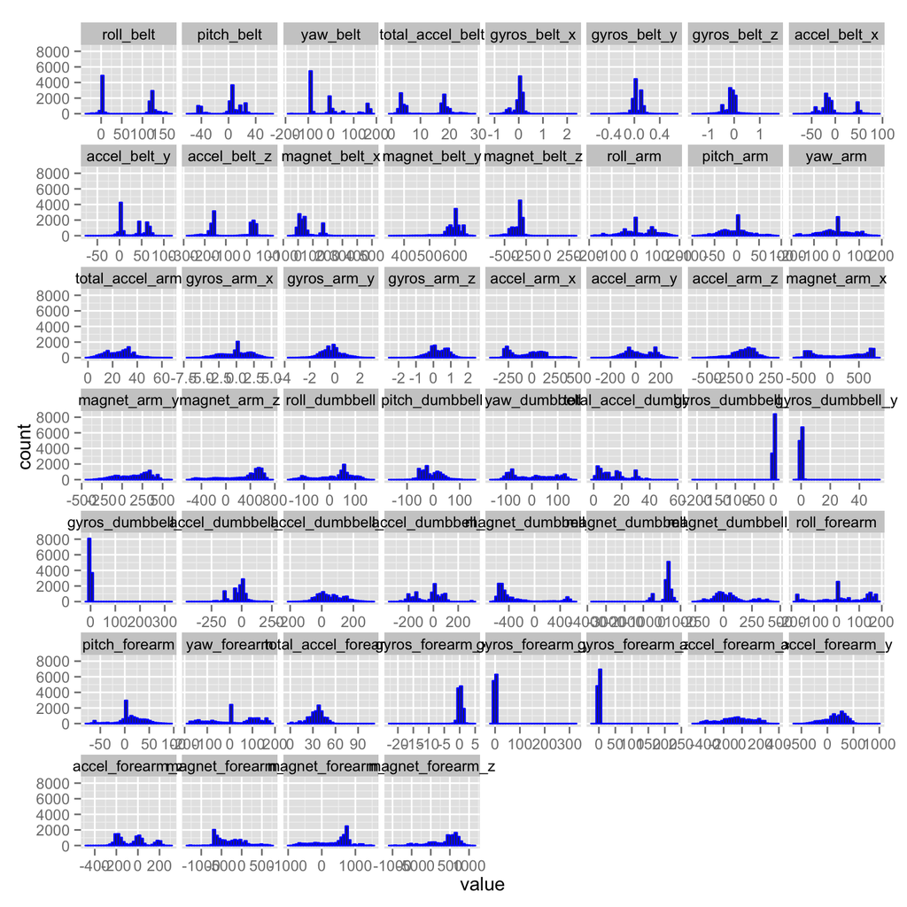

```r
outcome = which(names(train) == "classe")

train_melt <- melt(train[,-outcome])

ggplot(train_melt,aes(x = value)) +
    facet_wrap(~variable,scales = "free_x") +
    geom_histogram(color="blue")
```

Upon inspection it looks las if many of the variabels have similar distrbutions and may be related To examin this further we look for data correlation.

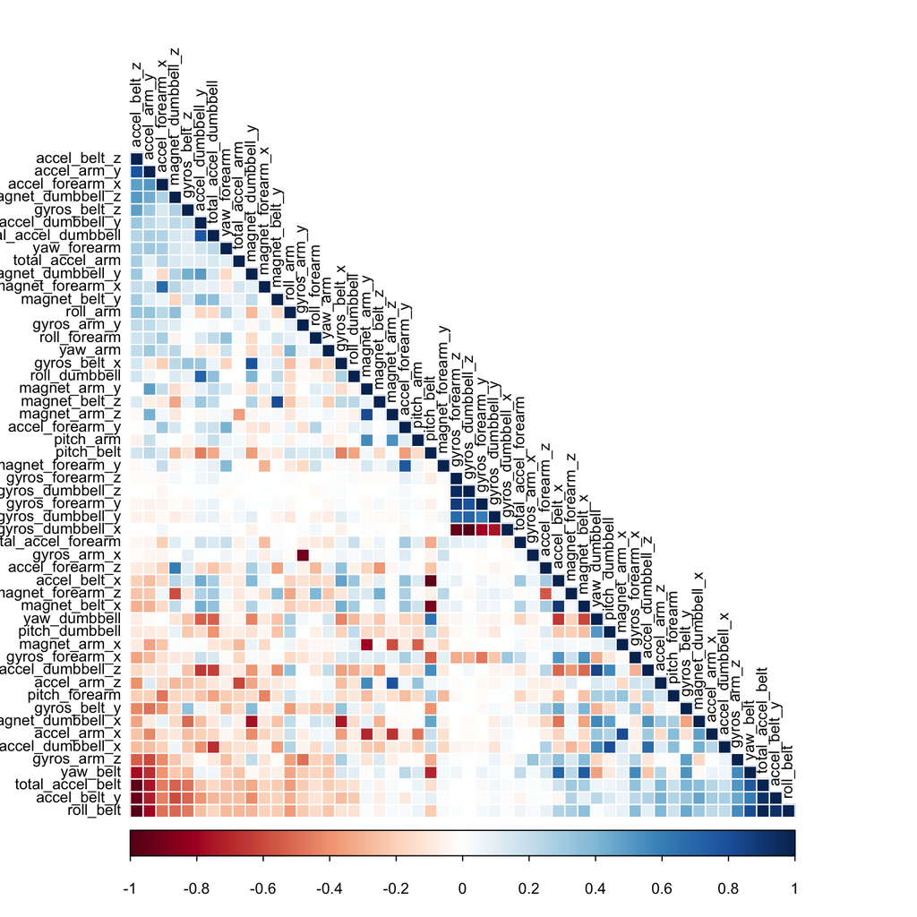

```r
c <- cor(train[,-outcome])
corrplot(c, order = "FPC", method = "color", type = "lower", tl.cex = 0.8,
         tl.col = rgb(0, 0, 0))
```

## Feature Selection

We see that many of the varialbes are indeed related, we want to remove these from the data to help ensure an accurate model. Any variables with a correlation greater than 80% will be removed.

```r
corr_cols = findCorrelation(abs(cor(train[,-outcome])),0.80)
corr_features = names(train)[corr_cols]
train = train[,-corr_cols]
```

The variables below are cooralated and have been removed.

accel_belt_z, roll_belt, accel_belt_y, accel_dumbbell_z, accel_belt_x, pitch_belt, accel_dumbbell_x, accel_arm_x, magnet_arm_y, magnet_belt_z, gyros_forearm_y, gyros_dumbbell_x, gyros_dumbbell_z, gyros_arm_x

## Training

Now that we have the features defined models will be created, k-Nearest Neighbor and Random Foest will be used.

```r
ctrlKNN = trainControl(method = "repeatedcv")
modelKNN = train(classe ~ ., train, method = "knn",
                 trControl = ctrlKNN,
                 preProcess=c("center","scale"))

ctrlRF = trainControl(method = "oob")
modelRF = train(classe ~ ., train, method = "rf",
                trControl = ctrlRF,
                ntree = 200,
                preProcess=c("center","scale"))
```

### k-Nearest Neighbor Errors

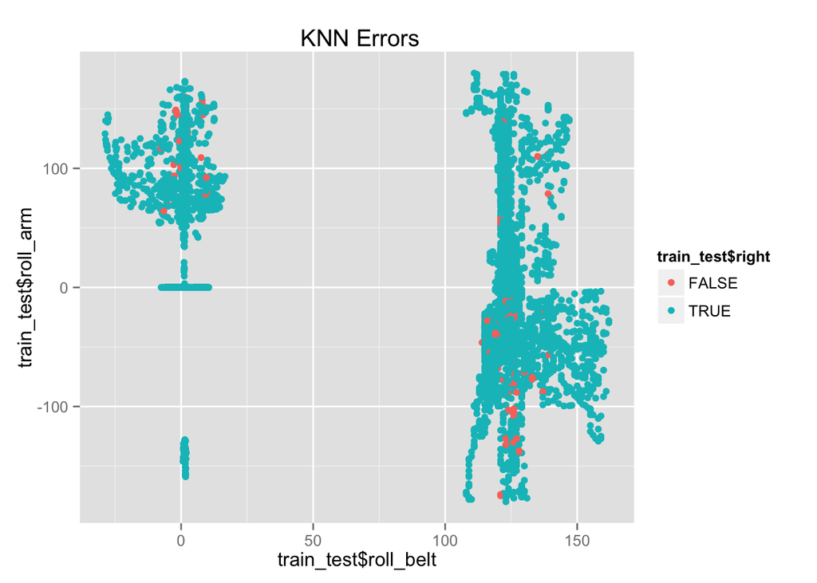

```r
fitKNN = predict(modelKNN, train_test)

train_test$right <- fitKNN == train_test$classe
qplot(train_test$roll_belt, train_test$roll_arm, colour=train_test$right, data=train_test,
      main=" KNN Errors")
```

```r
knn <- confusionMatrix(fitKNN, train_test$classe)
knn
```

```
## Confusion Matrix and Statistics
##
##           Reference
## Prediction    A    B    C    D    E
##          A 2199   57   10    3    3
##          B   10 1402   28    1   13
##          C   15   42 1295   57   20
##          D    7   11   27 1218   14
##          E    1    6    8    7 1392
##
## Overall Statistics
##
##                Accuracy : 0.9567
##                  95% CI : (0.9519, 0.9611)
##     No Information Rate : 0.2845
##     P-Value [Acc > NIR] : < 2.2e-16
##
##                   Kappa : 0.9452
##  Mcnemar's Test P-Value : 8.734e-11
##
## Statistics by Class:
##
##                      Class: A Class: B Class: C Class: D Class: E
## Sensitivity            0.9852   0.9236   0.9466   0.9471   0.9653
## Specificity            0.9870   0.9918   0.9793   0.9910   0.9966
## Pos Pred Value         0.9679   0.9642   0.9062   0.9538   0.9844
## Neg Pred Value         0.9941   0.9819   0.9886   0.9896   0.9922
## Prevalence             0.2845   0.1935   0.1744   0.1639   0.1838
## Detection Rate         0.2803   0.1787   0.1651   0.1552   0.1774
## Detection Prevalence   0.2896   0.1853   0.1821   0.1628   0.1802
## Balanced Accuracy      0.9861   0.9577   0.9630   0.9691   0.9809
```

### Random Forest Errors

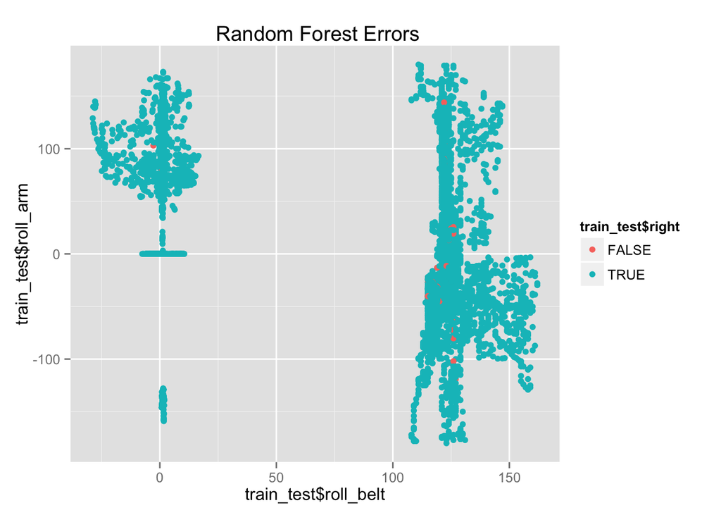

```r
fitRF = predict(modelRF, train_test)

train_test$right <- fitRF == train_test$classe
qplot(train_test$roll_belt, train_test$roll_arm, colour=train_test$right, data=train_test,
      main=" Random Forest Errors")
```

```r
rf <- confusionMatrix(fitRF, train_test$classe)
rf
```

```
## Confusion Matrix and Statistics
##
##           Reference
## Prediction    A    B    C    D    E
##          A 2230   18    0    1    0
##          B    1 1490   18    0    0
##          C    1    9 1335   23    2
##          D    0    0   15 1260    5
##          E    0    1    0    2 1435
##
## Overall Statistics
##
##                Accuracy : 0.9878
##                  95% CI : (0.9851, 0.9901)
##     No Information Rate : 0.2845
##     P-Value [Acc > NIR] : < 2.2e-16
##
##                   Kappa : 0.9845
##  Mcnemar's Test P-Value : NA
##
## Statistics by Class:
##
##                      Class: A Class: B Class: C Class: D Class: E
## Sensitivity            0.9991   0.9816   0.9759   0.9798   0.9951
## Specificity            0.9966   0.9970   0.9946   0.9970   0.9995
## Pos Pred Value         0.9916   0.9874   0.9745   0.9844   0.9979
## Neg Pred Value         0.9996   0.9956   0.9949   0.9960   0.9989
## Prevalence             0.2845   0.1935   0.1744   0.1639   0.1838
## Detection Rate         0.2842   0.1899   0.1702   0.1606   0.1829
## Detection Prevalence   0.2866   0.1923   0.1746   0.1631   0.1833
## Balanced Accuracy      0.9979   0.9893   0.9852   0.9884   0.9973
```

We see the Random Forest is 0.9877645 accurate with an out of sample error of 0.0122355. The KNN is 0.9566658 accurate out of sample error of 0.0433342.

The Random Forest model will be used on the test data

## Run Model Against Test Data

```r
testing  <- read.csv("pml-testing.csv", header=T,  na.strings = c("", "NA"))

test_results <- predict(modelRF, testing)

data.frame(test_results)
```

```
##    test_results
## 1             B
## 2             A
## 3             B
## 4             A
## 5             A
## 6             E
## 7             D
## 8             B
## 9             A
## 10            A
## 11            B
## 12            C
## 13            B
## 14            A
## 15            E
## 16            E
## 17            A
## 18            B
## 19            B
## 20            B
```